# PSTAT 131 Final Project: Model comparison for predicting the salary of a data science job

### Decision Regression Trees

```r
tree_salaries <- tree(salary_in_usd ~ ., data = encoded_salaries_train)

tree_salaries.cv = cv.tree(tree_salaries, K=5)
best_cv = min(tree_salaries.cv$size[tree_salaries.cv$dev == min(tree_salaries.cv$dev)])
```

Seems like the best tree fitted using this R function is the one with the size of 7 (the default fitted one)

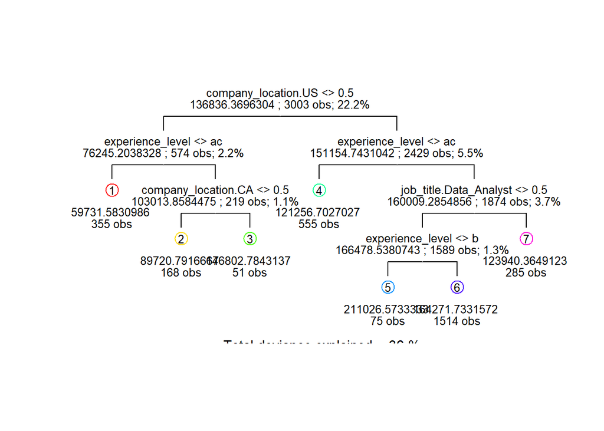

```r
draw.tree(tree_salaries, nodeinfo=TRUE, cex = 0.8)
```

Total deviance explained = 36 %. It doesn’t seem like we need to prune the tree, due to how less complex it is given the dataset with a huge amount of variables as we have right now. R seems to have already decided the important variables on its base iteration.

Tabling real values in salaries_train vs the predicted tree values

```r
predicted_values1 <- predict(tree_salaries, newdata = encoded_salaries_train)

comparison_table1 <- data.frame(Real = encoded_salaries_train$salary_in_usd, Predicted = predicted_values1)
```

```r
predicted_values2 <- predict(tree_salaries, newdata = encoded_salaries_test)

comparison_table2 <- data.frame(Real = encoded_salaries_test$salary_in_usd, Predicted = predicted_values2)
```

Visualization plot

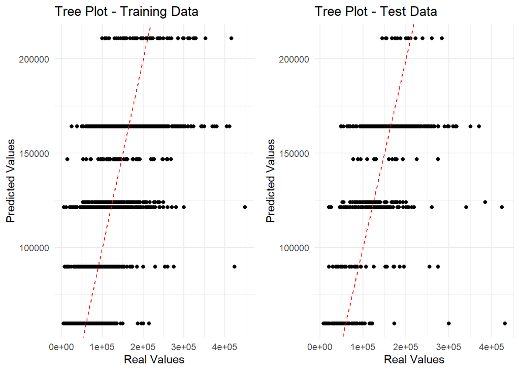

Train and Test MSE calculation

```r
residuals1 <- predicted_values1 - encoded_salaries_train$salary_in_usd
train_mse_tree <- mean(residuals1^2)
residuals2 <- predicted_values2 - encoded_salaries_test$salary_in_usd
test_mse_tree <- mean(residuals2^2)

train_mse_tree #2509462123
test_mse_tree #2818380612
```

### Random Forest Regression Trees

Fitting the regression tree (not specifying mtry sets it at p/3 for a regression tree)

```r
set.seed(123)
rf_salaries <- randomForest(salary_in_usd ~ ., data = encoded_salaries_train, importance=TRUE)
rf_salaries
```

Checking predicted values for both the train and test dataset to calculate the comparison tables which will later be used for plotting

```r
predicted_values3 <- predict(rf_salaries, newdata = encoded_salaries_train)
predicted_values4 <- predict(rf_salaries, newdata = encoded_salaries_test)
comparison_table3 <- data.frame(Real = encoded_salaries_train$salary_in_usd, Predicted = predicted_values3)
head(comparison_table3)
comparison_table4 <- data.frame(Real = encoded_salaries_test$salary_in_usd, Predicted = predicted_values4)
head(comparison_table4)
```

Visualizing the 2 fits

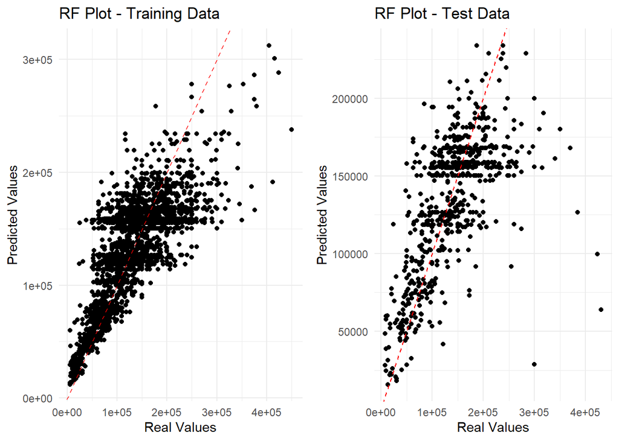

Calculating the MSE

```r
residuals3 <- predicted_values3 - encoded_salaries_train$salary_in_usd
residuals4 <- predicted_values4- encoded_salaries_test$salary_in_usd
train_mse_rf <- mean(residuals3^2)
test_mse_rf <- mean(residuals4^2)
train_mse_rf #1720059149
test_mse_rf #2524548390
```

The MSE is also observably lower than the previous MSE gotten from fitting a decision tree. We can still attempt to tune this even more though by trying the bagging method followed by boosting.

### Bagging

Fitting the bagged model

```r
set.seed(123)
bag_salaries <- randomForest(salary_in_usd ~ ., data = encoded_salaries_train, mtry = ncol(encoded_XTrain), importance=TRUE)
bag_salaries
```

Predicted values for train and test datasets based on the model

```r
predicted_values5 <- predict(bag_salaries, newdata = encoded_salaries_train)
predicted_values6 <- predict(bag_salaries, newdata = encoded_salaries_test)
comparison_table5 <- data.frame(Real = encoded_salaries_train$salary_in_usd, Predicted = predicted_values5)
head(comparison_table5)
comparison_table6 <- data.frame(Real = encoded_salaries_test$salary_in_usd, Predicted = predicted_values6)
head(comparison_table6)
```

Visualizing those tables

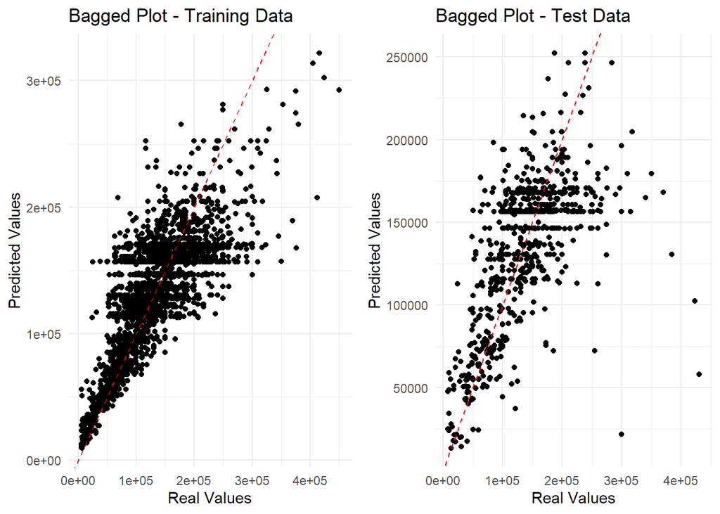

calculating train and test MSEs

```r
residuals5 <- predicted_values5 - encoded_salaries_train$salary_in_usd
residuals6 <- predicted_values6- encoded_salaries_test$salary_in_usd
train_mse_bag <- mean(residuals5^2)
test_mse_bag <- mean(residuals6^2)
train_mse_bag #1665896460
test_mse_bag #2581181189
```

### Boosting

Removing the variables with no variation

```r
boost_salaries_train <- encoded_salaries_train %>%
  select(-company_location.BA, -company_location.CL, -company_location.IR, -company_location.NZ)

boost_salaries_test <- encoded_salaries_test %>%
  select(-company_location.BA, -company_location.CL, -company_location.IR, -company_location.NZ)
```

Fitting the boosted model using gbm

```r
set.seed(123)
boost_salaries <- gbm(salary_in_usd ~ . ,
                      data = boost_salaries_train,
                      distribution = "gaussian",
                      n.trees = 500,
                      interaction.depth = 2)

#removed those variables as fitting the gbm with them gives a warning due to them not having variation
```

Summary to produce a relative influence plot as well as statistics

```r
#summary(boost_salaries) commented out due to taking up too much space
```

Predicted values for train and test datasets based on the model

```r
predicted_values7 <- predict(boost_salaries, newdata = encoded_salaries_train)
predicted_values8 <- predict(boost_salaries, newdata = encoded_salaries_test)
comparison_table7 <- data.frame(Real = encoded_salaries_train$salary_in_usd, Predicted = predicted_values7)
head(comparison_table7)
comparison_table8 <- data.frame(Real = encoded_salaries_test$salary_in_usd, Predicted = predicted_values8)
head(comparison_table8)
```

Visualizing those tables

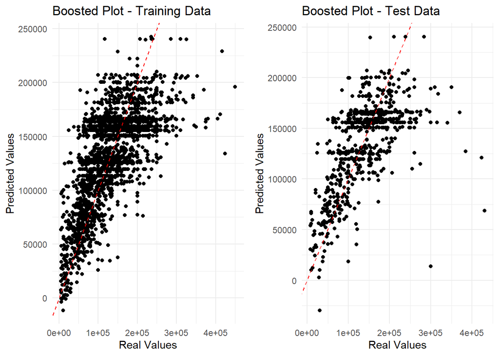

calculating train and test MSEs

```r
residuals7 <- predicted_values7 - encoded_salaries_train$salary_in_usd
residuals8 <- predicted_values8 - encoded_salaries_test$salary_in_usd
train_mse_boost <- mean(residuals7^2)
test_mse_boost <- mean(residuals8^2)
train_mse_boost #2166136013
test_mse_boost #2575802860
```

With 500 trees being fitted using this boosting method, we actually have a higher train MSE than the previous 2 tree methods but a slightly lower test mse than the bagging method. Once again making sense since we did not overfit the training MSE but are still less fitting than the default p/3 n.tree used in the random forest method.

## Part 3: Conclusion and comparisons

Tabling the MSEs

```r
options(max.print = 1000)
methods <- c("K-NN", "Linear Regression", "Decision Tree", "Random Forest", "Bagging", "Boosting")
train_mse_combination <- c(knn_mse_train, mse_nonlog, train_mse_tree, train_mse_rf, train_mse_bag, train_mse_boost)
test_mse_combination <- c(knn_mse_test, mse_test, test_mse_tree, test_mse_rf, test_mse_bag, test_mse_boost)

MSE_comparison_table <- data.frame(Method = methods, `Train MSE` = train_mse_combination, `Test MSE` = test_mse_combination)

MSE_comparison_table
```

```
##              Method  Train.MSE    Test.MSE
## 1              K-NN 2903523191  3560557411
## 2 Linear Regression 2098735946 23967797489
## 3     Decision Tree 2509462123  2818380612
## 4     Random Forest 1720059149  2524548390
## 5           Bagging 1665896460  2581181189
## 6          Boosting 2166136013  2575802860
```

From these observations, we can conclude that the Random Forest tree method is the best out of all the other methods.

What can we do to further improve on predicting the salary_in_usd? Due to how the earlier EDA portion was done prior to realizing I required encoding for alot of these methods, there was no comfortable way early on to pick out outliers/influential observations which may have resulted in a higher MSE. Also due to the limitations, I was not able to experiment with XGBoosting, which is a way more sophisticated method of fitting a decision tree, likely having a lower MSE than all these other methods. Another problem was the fact that despite using one-hot encoding, R was not able to display a complete tree in which it overfits through including every other predictor. It instead disappointingly fitted a decision tree with way less branches than I expected, ruining the chances of performing a tree-pruning/cv method to fit my own custom measure for fit. It may be wise to attempt similar methods in another programming language to fix these limitations, namely Python.